# TOP INSIGHTS FROM THE BIKE SHARING ANALYSIS

### by Samuel Tumilara Familusi

## Investigation Overview

In the investigation carried out on the bike sharing dataset, I explored the bike trip duration, and how different parameters can affect the trip duration. I found that user type, gender and start day, and what hour trips start in the day are important keys parameters that affect the bike trip duration

## Dataset Overview

This data set includes information about individual rides made in a ford bike-sharing system covering the greater San Francisco Bay area in February 2019, it has 183412 rowa and various columns containing features such as the duration, longitude, latitude.

## Visualization 1 : Duration Distribution

The duration distribution was skewed to the right due to outliers. These outliers were dropped, and I applied a log transform to the duration resulting in a unimodal distribution with its peak around 550

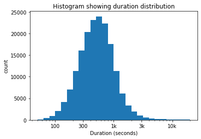

## Visualization 2 : Distribution of User Type

Investigating the user type shows that Subscribers take a lot more trips than regular customers

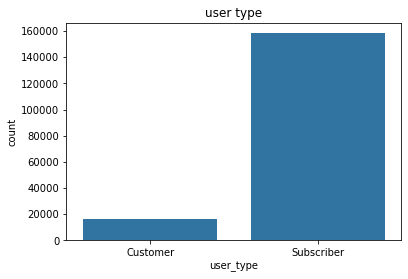

## Visualization 3 : Distribution of Start day, user type, gender and duration

Investigation how these multi values shows that customers ride for a longer duration on average, while men ride the least. It also shows that the duration of rides are higher on saturdays and sundays.

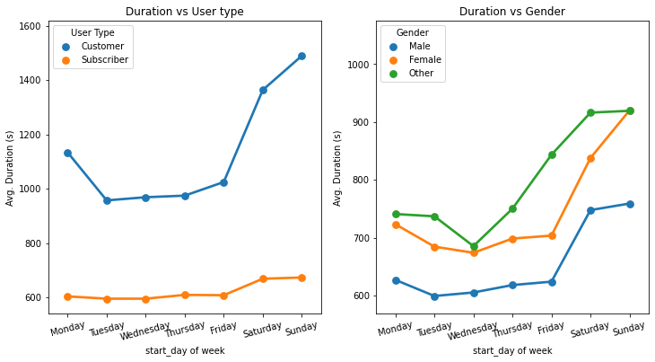

# Insights into the data

1. People spend longer riding on saturdays and sundays
2. There are more people renting bikes for trips to and from work
3. There is an even distribution of genders but there are more male riders.
4. There is very little correlation between duration and distance

# Recommendation

1. The organization should look into converting more customers to subscribers a. They could offer work hour riders that are not subscribers a deal b. They could offer female riders a coupon. This will drive up female riders and evental subscribers